# Indicators of student success in a college level course

Josh Schechter, Naiyani Paladugu, Lincoln Orellana

05-04-2025

# Introduction

When constructing and teaching a college-level course over time, a professor should should be able to identify tendencies and characteristics of students who are likely to perform well in the course. If the professor can identify these tendencies, it can help to ensure that the course is being taught in a way that is accessible and fair to all students, provide proper guidance for students to know what will be likely to make them successful, and identify what improvements could be made in the course based on previous data. Our goals are to identify the key characteristics, tendencies, and predictors of students who are unlikely to success in the course.

Our research questions are as follows:

1. What features are the best predictors of student success in a college-level course?
2. Can we create a model that accurately predicts passing/failing?

```r
library(dplyr)
library(readr)
```

```r
library(ggplot2)
library(tidyr)
library(caret)
library(pROC)
library(MASS)
library(rpart)
library(randomForest)
students <- read.csv("../data/Students_Grading_Dataset_Cleaned.csv")
```

# Explanation of Data and Preprocessing

- Letter Grade (categorical)
- Total Score (numeric)
- Study hours per week (numeric)
- Attendance (numeric)
- Stress levels (ordinal)
- Sleep hours per night (numeric)
- Family income level (ordinal)
- Extracurricular activities (binary)

Of the dataset given, the logical target variables are Letter Grade, and Total Score. However, our goal is to breakdown the target variable into a binary pass/fail variable. We therefore engineered a variable called Pass_Fail to be our target variable. For students who received an A, B, or C in the course, they were assigned a Pass_Fail value of 1, representing a pass. For students who received before a C, they were assigned a Pass_Fail value of 0, representing a fail. This was done to ensure that the model would be able to predict pass/fail, and not just the letter grade. The data is now set up, allowing us to move on to EDA.

# Exploratory Data Analysis (EDA)

```r
colnames(students)
```

```
##  [1] "Student_ID"                 "First_Name"
##  [3] "Last_Name"                  "Email"
##  [5] "Gender"                     "Age"
##  [7] "Department"                 "Attendance"
##  [9] "Midterm_Score"              "Final_Score"
## [11] "Assignments_Avg"            "Quizzes_Avg"
## [13] "Participation_Score"        "Projects_Score"
## [15] "Total_Score"                "Grade"
## [17] "Study_Hours_per_Week"       "Extracurricular_Activities"
## [19] "Internet_Access_at_Home"    "Parent_Education_Level"
## [21] "Family_Income_Level"        "Stress_Level"
## [23] "Sleep_Hours_per_Night"      "Pass_Fail"
```

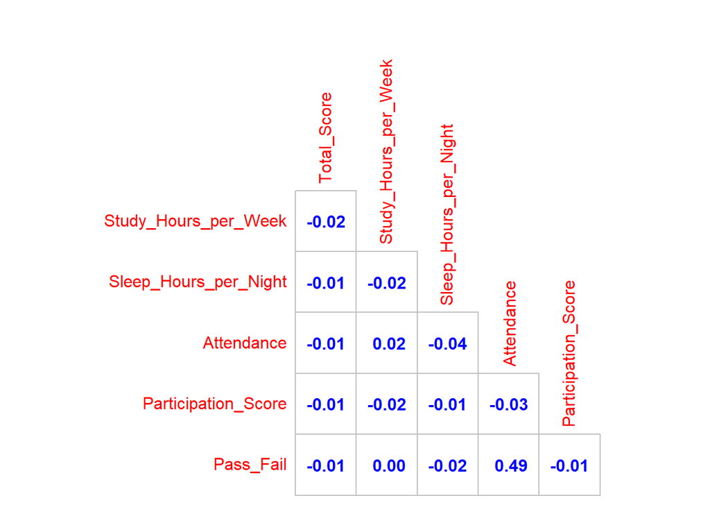

```r
cor_mat <- cor(students[, c("Total_Score", "Study_Hours_per_Week",
                         "Sleep_Hours_per_Night",
                         "Attendance", "Participation_Score",
                         'Pass_Fail')])


corrplot::corrplot(cor_mat,
                   method="number",
                   col="blue",
                   type="lower",
                   cl.pos='n',
                   diag=FALSE)
```

The correlation matrix revealed that most variables, including Total Score, Study Hours per Week, Sleep Hours per Night, Attendance, Participation Score, and Pass/Fail, have very weak linear relationships, with correlations close to zero. The only moderately strong relationship was between Attendance and Pass/Fail (correlation of 0.49), suggesting that students who attended class more frequently were more likely to pass. This insight points to attendance as a meaningful predictor for student success.

```r
summary(students)
```

```
##   Student_ID         First_Name         Last_Name            Email
##  Length:3230        Length:3230        Length:3230        Length:3230
##  Class :character   Class :character   Class :character   Class :character
##  Mode  :character   Mode  :character   Mode  :character   Mode  :character
##
##
##
##     Gender               Age         Department          Attendance
##  Length:3230        Min.   :18.00   Length:3230        Min.   : 50.01
##  Class :character   1st Qu.:19.00   Class :character   1st Qu.: 63.36
##  Mode  :character   Median :21.00   Mode  :character   Median : 75.73
##                     Mean   :21.03                      Mean   : 75.42
##                     3rd Qu.:23.00                      3rd Qu.: 87.30
##                     Max.   :24.00                      Max.   :100.00
##  Midterm_Score    Final_Score    Assignments_Avg  Quizzes_Avg
##  Min.   :40.01   Min.   :40.00   Min.   :50.00   Min.   :50.03
##  1st Qu.:55.39   1st Qu.:54.66   1st Qu.:62.07   1st Qu.:62.48
##  Median :69.89   Median :69.75   Median :74.98   Median :74.81
##  Mean   :70.10   Mean   :69.49   Mean   :74.98   Mean   :74.88
##  3rd Qu.:84.59   3rd Qu.:84.00   3rd Qu.:87.42   3rd Qu.:87.35
##  Max.   :99.97   Max.   :99.98   Max.   :99.98   Max.   :99.95
##  Participation_Score Projects_Score    Total_Score       Grade
##  Min.   : 0.000      Min.   : 50.01   Min.   :50.03   Length:3230
##  1st Qu.: 2.502      1st Qu.: 62.22   1st Qu.:62.84   Class :character
##  Median : 5.020      Median : 74.97   Median :74.92   Mode  :character
##  Mean   : 5.010      Mean   : 74.85   Mean   :74.90
##  3rd Qu.: 7.518      3rd Qu.: 87.14   3rd Qu.:87.48
##  Max.   :10.000      Max.   :100.00   Max.   :99.99
##  Study_Hours_per_Week Extracurricular_Activities Internet_Access_at_Home
##  Min.   : 5.00        Length:3230                Length:3230
##  1st Qu.:11.50        Class :character           Class :character
##  Median :17.40        Mode  :character           Mode  :character
##  Mean   :17.68
##  3rd Qu.:24.10
##  Max.   :30.00
##  Parent_Education_Level Family_Income_Level  Stress_Level
##  Length:3230            Length:3230         Min.   : 1.000
##  Class :character       Class :character    1st Qu.: 3.000
##  Mode  :character       Mode  :character    Median : 5.000
##                                             Mean   : 5.482
##                                             3rd Qu.: 8.000
##                                             Max.   :10.000
##  Sleep_Hours_per_Night   Pass_Fail
##  Min.   :4.000         Min.   :0.0000
##  1st Qu.:5.200         1st Qu.:0.0000
##  Median :6.500         Median :1.0000
##  Mean   :6.476         Mean   :0.6656
##  3rd Qu.:7.700         3rd Qu.:1.0000
##  Max.   :9.000         Max.   :1.0000
```

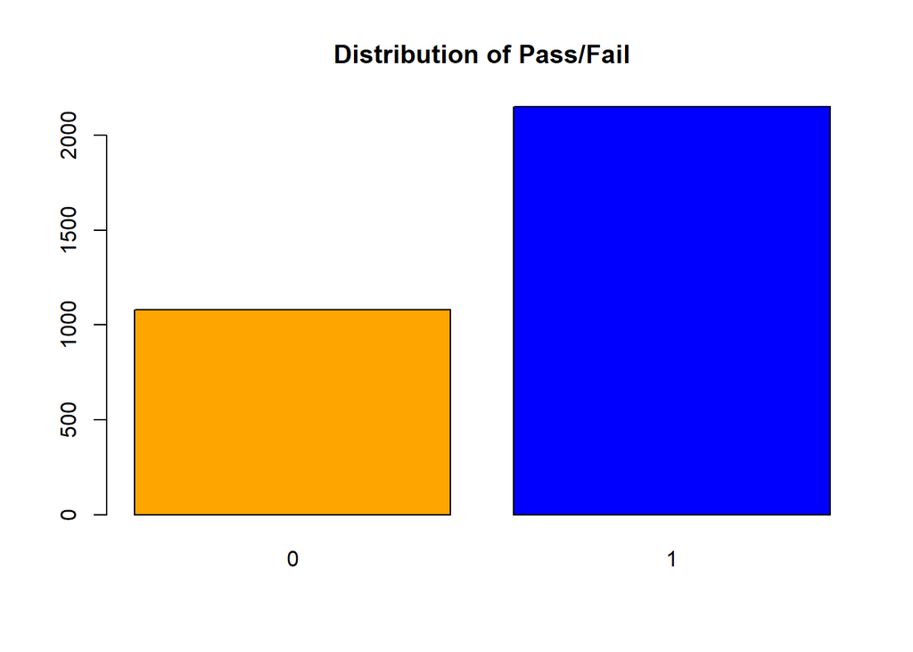

```r
barplot(table(students$Pass_Fail), col=c('orange','blue'), main = "Distribution of Pass/Fail")
```

```r
table(students$Pass_Fail)
```

```
##
##    0    1
## 1080 2150
```

The bar plot of Pass_Fail distribution showed that the majority of students passed, as indicated by the taller blue bar representing pass status (1), compared to the shorter orange bar representing fail status (0). This indicates an imbalanced dataset, which is important to keep in mind because classification models may need balancing techniques like resampling or weighting to handle the imbalance.

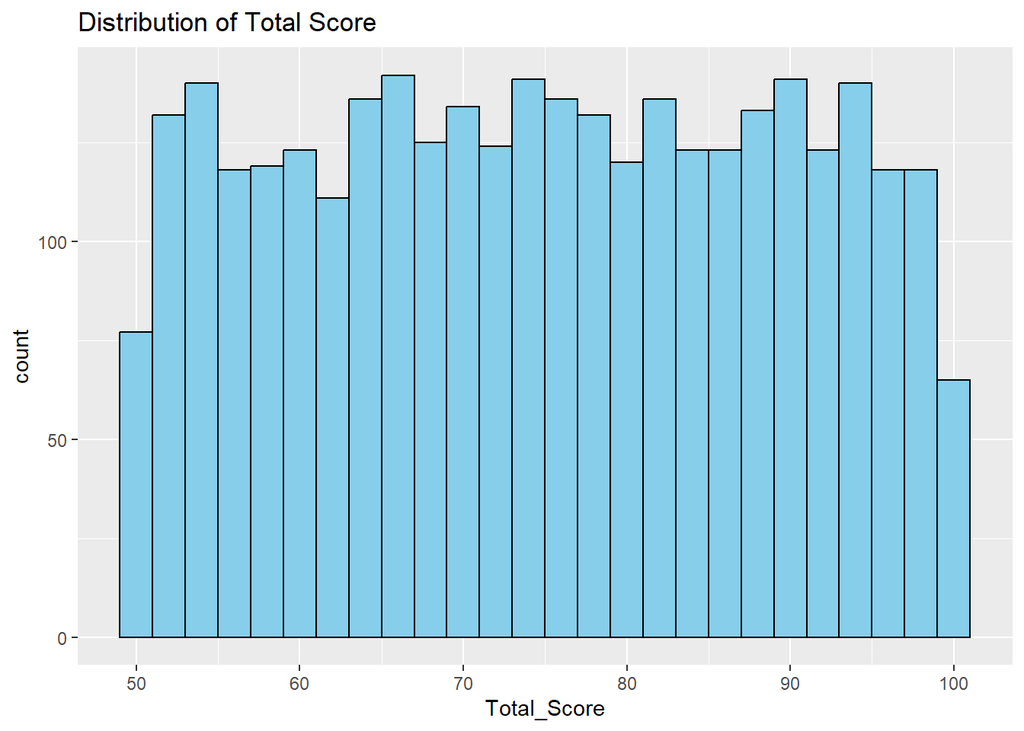

```r
ggplot(students, aes(x = Total_Score)) +
  geom_histogram(binwidth = 2, fill = "skyblue", color = "black") +
  labs(title = "Distribution of Total Score")
```

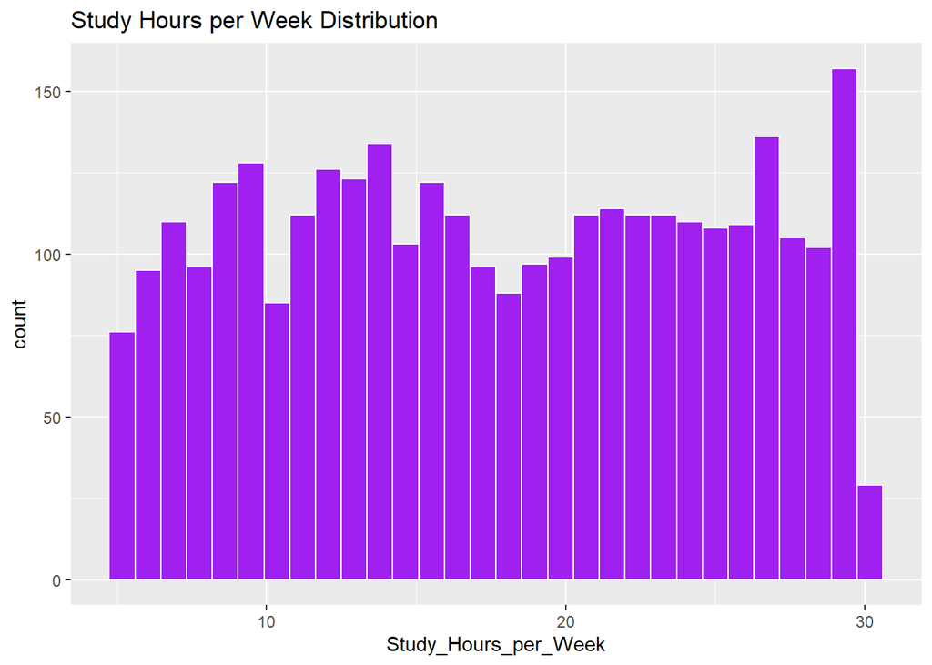

```r
ggplot(students, aes(x = Study_Hours_per_Week)) +
  geom_histogram(fill = "purple", color = "white") +
  labs(title = "Study Hours per Week Distribution")
```

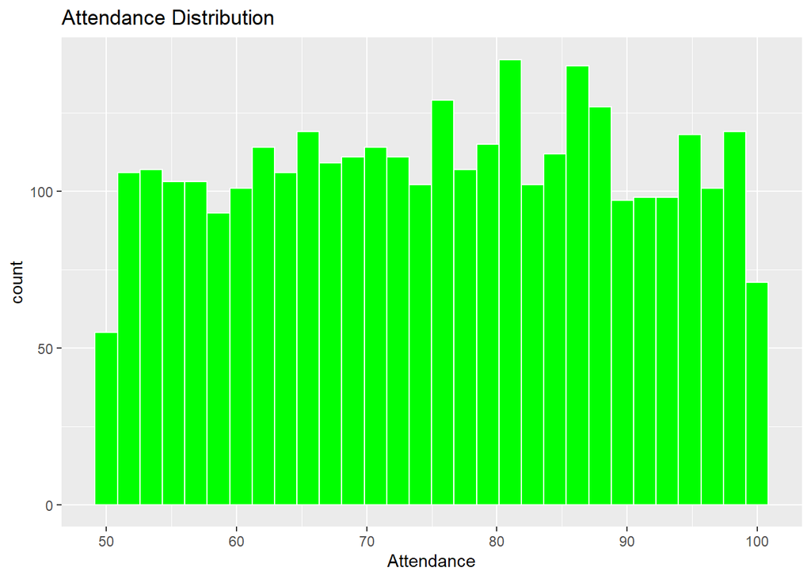

```r
ggplot(students, aes(x = Attendance)) +
  geom_histogram(fill = "green", color = "white") +
  labs(title = "Attendance Distribution")
```

The histogram of Total Score demonstrated that student scores are roughly uniformly distributed between 50 and 100, without strong skew toward the lower or upper ends. This suggests that the grading scale was fair, and the distribution of performance among students was even, without large groups clustering at failing or perfect scores.

The attendance distribution histogram revealed that students’ attendance rates were fairly evenly spread, but with more students clustering around 80–90% attendance. This pattern reinforces the importance of attendance as a factor related to student outcomes, as seen earlier in the correlation analysis.

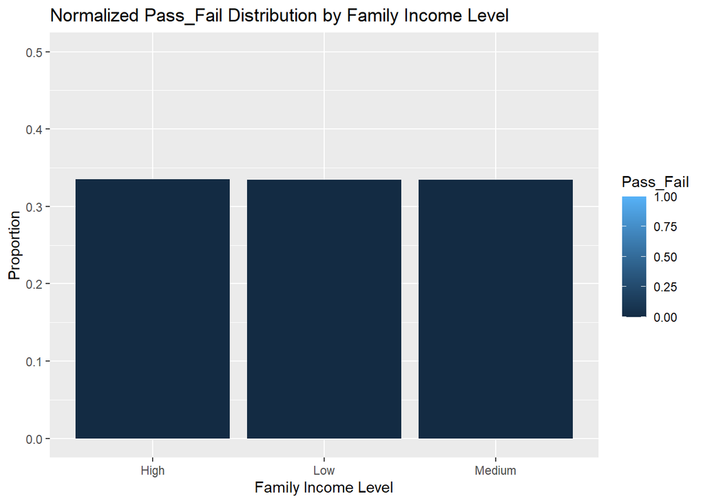

```r
students %>%
  count(Family_Income_Level, Pass_Fail) %>%
  group_by(Family_Income_Level) %>%
  mutate(Proportion = n / sum(n)) %>%
  ggplot(aes(x = Family_Income_Level, y = Proportion, fill = Pass_Fail)) +
  geom_bar(stat = "identity", position = "dodge") +
  labs(title = "Normalized Pass_Fail Distribution by Family Income Level",
       x = "Family Income Level", y = "Proportion") +
  ylim(0,0.5)
```

The normalized bar plot of Pass/Fail by Family Income Level showed that the proportion of students passing was quite similar across high, medium, and low-income groups. This suggests that family income did not have a major effect on academic success in this dataset, an important finding for considering fairness and potential biases when building predictive models.

```r
students$Total_Score <- as.numeric(students$Total_Score)
students$Study_Hours_per_Week <- as.numeric(students$Study_Hours_per_Week)
students$Sleep_Hours_per_Night <- as.numeric(students$Sleep_Hours_per_Night)
students$Stress_Level <- as.numeric(students$Stress_Level)
```

Next, to ensure a balanced dataset, we decided to upsample the data. This is a common technique used to balance the dataset by increasing the number of instances in the minority class. In this case, we will upsample the failing students to match the number of passing students. This will help improve the performance of our classification models.

```r
students$Pass_Fail <- factor(students$Pass_Fail, levels = c(0, 1), labels = c("Fail", "Pass"))
set.seed(123)  # for reproducibility
students <- upSample(x = students[, setdiff(names(students), "Pass_Fail")],
                               y = students$Pass_Fail,
                               yname = "Pass_Fail")

# Check class balance
table(students$Pass_Fail)
```

```
##
## Fail Pass
## 2150 2150
```

```r
students$Pass_Fail <- ifelse(students$Pass_Fail == "Fail", 0, 1)
```

# Linear Regression

After our findings in EDA, we wanted to see if we could create a linear model for infering total score based on predictors. Our initial thought was to use the following predictors:

1. Attendance
2. Sleep Hours per Night
3. Study Hours per Week
4. Stress Level
5. Family Income Level
6. Extracurricular Activities
7. Internet Access at Home

From there, we would run a stepwise selection to see if we could find a model with less predictors that still yields similar results.

```r
full_lin_reg_model <- lm(Total_Score ~ Attendance + Sleep_Hours_per_Night + Study_Hours_per_Week + Stress_Level + Family_Income_Level + Extracurricular_Activities + Internet_Access_at_Home, data = students)
summary(full_lin_reg_model)
```

```
##
## Call:
## lm(formula = Total_Score ~ Attendance + Sleep_Hours_per_Night +
##     Study_Hours_per_Week + Stress_Level + Family_Income_Level +
##     Extracurricular_Activities + Internet_Access_at_Home, data = students)
##
## Residuals:
##    Min     1Q Median     3Q    Max
## -26.40 -11.97  -0.04  12.70  26.02
##
## Coefficients:
##                                Estimate Std. Error t value Pr(>|t|)
## (Intercept)                   75.685513   1.848989  40.933  < 2e-16 ***
## Attendance                    -0.009835   0.015578  -0.631  0.52786
## Sleep_Hours_per_Night          0.030939   0.150261   0.206  0.83687
## Study_Hours_per_Week          -0.047029   0.030378  -1.548  0.12166
## Stress_Level                   0.111881   0.077664   1.441  0.14978
## Family_Income_LevelLow         1.611592   0.600998   2.682  0.00736 **
## Family_Income_LevelMedium      0.706573   0.598303   1.181  0.23768
## Extracurricular_ActivitiesYes  0.038004   0.482448   0.079  0.93722
## Internet_Access_at_HomeYes    -0.905721   0.726258  -1.247  0.21243
## ---
## Signif. codes:  0 '***' 0.001 '**' 0.01 '*' 0.05 '.' 0.1 ' ' 1
##
## Residual standard error: 14.47 on 4291 degrees of freedom
## Multiple R-squared:  0.003305,   Adjusted R-squared:  0.001447
## F-statistic: 1.778 on 8 and 4291 DF,  p-value: 0.07635
```

```r
lin_reg_stepwise_model <- stepAIC(full_lin_reg_model, direction = "both", trace = FALSE)

# View selected model summary
summary(lin_reg_stepwise_model)
```

```
##
## Call:
## lm(formula = Total_Score ~ Study_Hours_per_Week + Stress_Level +
##     Family_Income_Level, data = students)
##
## Residuals:
##      Min       1Q   Median       3Q      Max
## -26.2049 -12.1050   0.0292  12.8050  26.1442
##
## Coefficients:
##                           Estimate Std. Error t value Pr(>|t|)
## (Intercept)               74.38158    0.84224  88.314  < 2e-16 ***
## Study_Hours_per_Week      -0.04728    0.03036  -1.558  0.11941
## Stress_Level               0.11350    0.07762   1.462  0.14371
## Family_Income_LevelLow     1.59011    0.59957   2.652  0.00803 **
## Family_Income_LevelMedium  0.68504    0.59738   1.147  0.25155
## ---
## Signif. codes:  0 '***' 0.001 '**' 0.01 '*' 0.05 '.' 0.1 ' ' 1
##
## Residual standard error: 14.47 on 4295 degrees of freedom
## Multiple R-squared:  0.00284,    Adjusted R-squared:  0.001912
## F-statistic: 3.059 on 4 and 4295 DF,  p-value: 0.01579
```

Post stepwise selection, we were left with four predictors:

1. Study Hours per Week
2. Stress Level
3. Family Income Level-Low
4. Family Income Level-Medium

With an alpha= 0.05, only family income level-low had a statistically significant p-value. This is an indication that family income level does in fact have some sort of a significant relationship with inferring total score in this linear regression model. The other predictors were not statistically significant, however they were recommended by the stepwise algorithm, which indicates that they did impact the model.

Our linear regression formula is as follows:

y = 74.38158 + -0.04728 * Study_Hours_per_Week + 0.11350 * Stress_Level + 1.59011 * Family_Income_LevelLow + 0.68504 * Family_Income_LevelMedium

Notably, our model is statistically very weak, with a multiple r-squared value of 0.00284, indicating that our model only explains 0.284% of the variance in total score. Given this is a very low percentage, we can conclude that this model alone is not a good predictor of total score.

# Logistic Regression

The next model we set out to build was a logistic regression model to predict pass/fail based on the same indicators as our linear regression model. Once again, we ran a stepwise model comparison to determine which model would yield the best results with the least amount of predictors.

```r
full_logit_model <- glm(Pass_Fail ~ Attendance + Family_Income_Level + Extracurricular_Activities + Internet_Access_at_Home + Sleep_Hours_per_Night + Study_Hours_per_Week + Stress_Level,
                   data = students,
                   family = binomial)

# Stepwise selection
stepwise_logit_model <- stepAIC(full_logit_model, direction = "both")
```

```
## Start:  AIC=4620.33
## Pass_Fail ~ Attendance + Family_Income_Level + Extracurricular_Activities +
##     Internet_Access_at_Home + Sleep_Hours_per_Night + Study_Hours_per_Week +
##     Stress_Level
##
##                              Df Deviance    AIC
## - Extracurricular_Activities  1   4602.4 4618.4
## - Study_Hours_per_Week        1   4602.4 4618.4
## - Sleep_Hours_per_Night       1   4602.4 4618.4
## - Stress_Level                1   4603.4 4619.4
## - Internet_Access_at_Home     1   4604.2 4620.2
## <none>                            4602.3 4620.3
## - Family_Income_Level         2   4607.9 4621.9
## - Attendance                  1   5956.7 5972.7
##
## Step:  AIC=4618.38
## Pass_Fail ~ Attendance + Family_Income_Level + Internet_Access_at_Home +
##     Sleep_Hours_per_Night + Study_Hours_per_Week + Stress_Level
##
##                              Df Deviance    AIC
## - Study_Hours_per_Week        1   4602.4 4616.4
## - Sleep_Hours_per_Night       1   4602.5 4616.5
## - Stress_Level                1   4603.4 4617.4
## - Internet_Access_at_Home     1   4604.2 4618.2
## <none>                            4602.4 4618.4
## - Family_Income_Level         2   4607.9 4619.9
## + Extracurricular_Activities  1   4602.3 4620.3
## - Attendance                  1   5956.7 5970.7
##
## Step:  AIC=4616.43
## Pass_Fail ~ Attendance + Family_Income_Level + Internet_Access_at_Home +
##     Sleep_Hours_per_Night + Stress_Level
##
##                              Df Deviance    AIC
## - Sleep_Hours_per_Night       1   4602.5 4614.5
## - Stress_Level                1   4603.5 4615.5
## - Internet_Access_at_Home     1   4604.3 4616.3
## <none>                            4602.4 4616.4
## - Family_Income_Level         2   4608.0 4618.0
## + Study_Hours_per_Week        1   4602.4 4618.4
```

[output cut: 27 more lines]

```
## + Extracurricular_Activities  1   4603.5 4615.5
## - Attendance                  1   5958.7 5966.7
##
## Step:  AIC=4613.44
## Pass_Fail ~ Attendance + Family_Income_Level
##
##                              Df Deviance    AIC
## <none>                            4605.4 4613.4
## + Internet_Access_at_Home     1   4603.5 4613.5
## + Stress_Level                1   4604.3 4614.3
## - Family_Income_Level         2   4610.7 4614.7
## + Sleep_Hours_per_Night       1   4605.4 4615.4
## + Extracurricular_Activities  1   4605.4 4615.4
## + Study_Hours_per_Week        1   4605.4 4615.4
## - Attendance                  1   5960.5 5966.5
```

```r
summary(stepwise_logit_model)
```

```
##
## Call:
## glm(formula = Pass_Fail ~ Attendance + Family_Income_Level, family = binomial,
##     data = students)
##
## Coefficients:
##                            Estimate Std. Error z value Pr(>|z|)
## (Intercept)               -6.906600   0.235062 -29.382   <2e-16 ***
## Attendance                 0.094121   0.003025  31.116   <2e-16 ***
## Family_Income_LevelLow     0.179478   0.097863   1.834   0.0667 .
## Family_Income_LevelMedium  0.013696   0.097217   0.141   0.8880
## ---
## Signif. codes:  0 '***' 0.001 '**' 0.01 '*' 0.05 '.' 0.1 ' ' 1
##
## (Dispersion parameter for binomial family taken to be 1)
##
##     Null deviance: 5961.1  on 4299  degrees of freedom
## Residual deviance: 4605.4  on 4296  degrees of freedom
## AIC: 4613.4
##
## Number of Fisher Scoring iterations: 4
```

**Stepwise Feature Selection Results**

Post stepwise regression, we were left with just tree predictors:

1. Attendance (significant)
2. Family Income Level-Low (borderline)
3. Family Income Level-Medium

```r
final_logit_model <- glm(Pass_Fail ~ Attendance + Family_Income_Level,
                   data = students)

summary(final_logit_model)
```

```
##
## Call:
## glm(formula = Pass_Fail ~ Attendance + Family_Income_Level, data = students)
##
## Coefficients:
##                             Estimate Std. Error t value Pr(>|t|)
## (Intercept)               -0.8791872  0.0362967 -24.222   <2e-16 ***
## Attendance                 0.0187739  0.0004555  41.218   <2e-16 ***
## Family_Income_LevelLow     0.0296613  0.0175511   1.690   0.0911 .
## Family_Income_LevelMedium  0.0015142  0.0174777   0.087   0.9310
## ---
## Signif. codes:  0 '***' 0.001 '**' 0.01 '*' 0.05 '.' 0.1 ' ' 1
##
## (Dispersion parameter for gaussian family taken to be 0.1792946)
##
##     Null deviance: 1075.00  on 4299  degrees of freedom
## Residual deviance:  770.25  on 4296  degrees of freedom
## AIC: 4818.4
##
## Number of Fisher Scoring iterations: 2
```

```r
students$predictions <- predict(final_logit_model, type = "response")
```

Now that our model is built, and we have made our probabilities for each datapoint via the model, we will set the threshold to 0.5, as the dataset has been upsampled already.

```r
students$predicted_class <- ifelse(students$predictions > 0.5, 1, 0)
students$predicted_class <- factor(students$predicted_class, levels = c(0, 1), labels = c("Fail", "Pass"))
```

```r
students$Pass_Fail <- as.numeric(as.character(students$Pass_Fail))
students$Pass_Fail <- factor(students$Pass_Fail, levels = c(0, 1), labels = c("Fail", "Pass"))
```

```r
table(students$predicted_class, useNA = "always")
```

```
##
## Fail Pass <NA>
## 2195 2105    0
```

```r
table(students$Pass_Fail, useNA = "always")
```

```
##
## Fail Pass <NA>
## 2150 2150    0
```

```r
# Now evaluate with confusion matrix
students$Pass_Fail <- factor(students$Pass_Fail, levels = c("Fail", "Pass"))
confusionMatrix(students$predicted_class, students$Pass_Fail, positive = "Pass")
```

```
## Confusion Matrix and Statistics
##
##           Reference
## Prediction Fail Pass
##       Fail 1536  659
##       Pass  614 1491
##
##                Accuracy : 0.704
##                  95% CI : (0.6901, 0.7176)
##     No Information Rate : 0.5
##     P-Value [Acc > NIR] : <2e-16
##
##                   Kappa : 0.4079
##
##  Mcnemar's Test P-Value : 0.2175
##
##             Sensitivity : 0.6935
##             Specificity : 0.7144
##          Pos Pred Value : 0.7083
##          Neg Pred Value : 0.6998
##              Prevalence : 0.5000
##          Detection Rate : 0.3467
##    Detection Prevalence : 0.4895
##       Balanced Accuracy : 0.7040
##
##        'Positive' Class : Pass
##
```

**Analyzing LOGIT Results and Confusion Matrix**

To analyze the results, we built a confusion matrix. The main metrics that we will be looking at are:

1. Sensitivity (Recall for pass), for all actual passing students, what proportion was predicted as passing?
2. Specificity (Recall for fail), for all actual failing students, what proportion was predicted as failing?

For sensitivity, the score was 0.6935. It can be said that 69.35% of all actual passing students were predicted to pass the course. For specificity, the score was 0.7144. It can be said that 71.44% of all actual failing students were predicted to fail the course. For our use case, we can make the claim that this is a good model. As not only is it approximately good at predicting both, but it is able to identify students who are likely to fail the course at a fairly high rate.

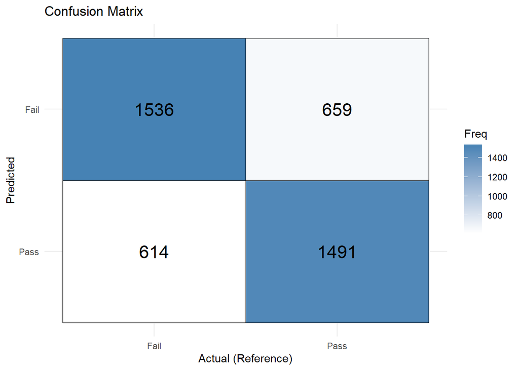

```r
conf_mat <- confusionMatrix(students$predicted_class, students$Pass_Fail, positive = "Pass")
conf_mat_df <- as.data.frame(conf_mat$table)
ggplot(data = conf_mat_df, aes(x = Reference, y = Prediction, fill = Freq)) +
  geom_tile(color = "black") +
  geom_text(aes(label = Freq), size = 6) +
  scale_fill_gradient(low = "white", high = "steelblue") +
  scale_y_discrete(limits = rev(levels(conf_mat_df$Prediction))) +
  theme_minimal() +
  labs(
    title = "Confusion Matrix",
    x = "Actual (Reference)",
    y = "Predicted"
  )
```

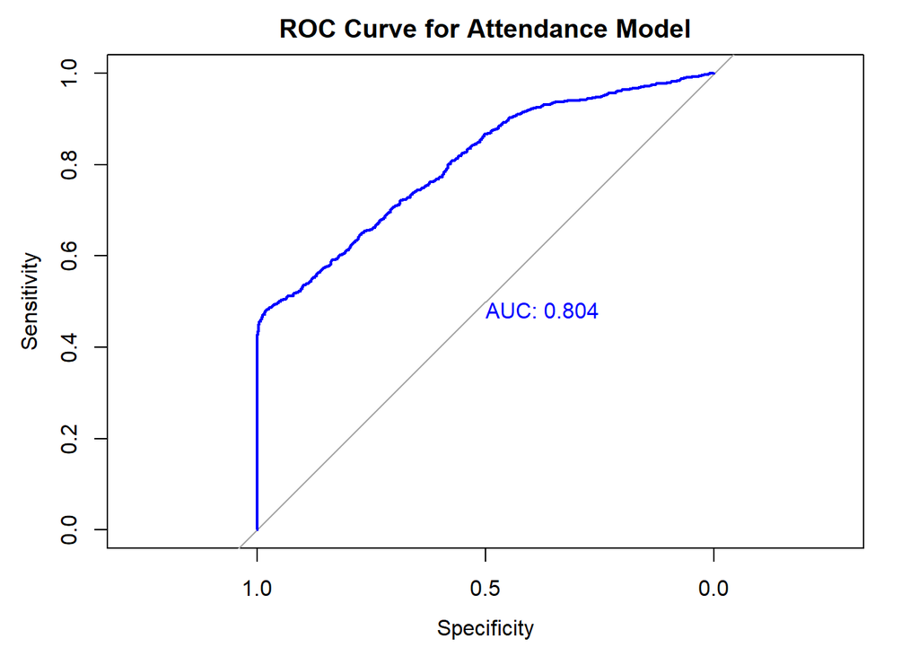

```
##
## Call:
## roc.default(response = students$Pass_Fail, predictor = predict(final_logit_model,     type = "response"), plot = TRUE, main = "ROC Curve for Attendance Model",     print.auc = TRUE, col = "blue", lwd = 2)
##
## Data: predict(final_logit_model, type = "response") in 2150 controls (students$Pass_Fail Fail) < 2150 cases (students$Pass_Fail Pass).
## Area under the curve: 0.8037
```

```r
roc(students$Pass_Fail,
    main="ROC Curve for Attendance Model",
    predict(final_logit_model, type = "response"),
    plot = TRUE,
    print.auc = TRUE,
    col = "blue",
    lwd = 2)
```

**LOGIT ROC Curve**

# Random Forest

```r
# Building random forest model
set.seed(1)
rf_model <- randomForest(Pass_Fail ~ Attendance + Family_Income_Level + Extracurricular_Activities + Internet_Access_at_Home,
                         data = students,
                         ntree = 500,
                         mtry = 2,
                         importance = TRUE)

print(rf_model)
```

```
##
## Call:
##  randomForest(formula = Pass_Fail ~ Attendance + Family_Income_Level +      Extracurricular_Activities + Internet_Access_at_Home, data = students,      ntree = 500, mtry = 2, importance = TRUE)
##                Type of random forest: classification
##                      Number of trees: 500
## No. of variables tried at each split: 2
##
##         OOB estimate of  error rate: 26.12%
## Confusion matrix:
##      Fail Pass class.error
## Fail 2078   72  0.03348837
## Pass 1051 1099  0.48883721
```

We chose to use a Random Forest model as it’s a powerful machine learning technique that works by combining several decision trees to make better predictions. We selected the following features based on their potential influence on academic performance:

- Attendance
- Family Income Level
- Extracurricular Activities
- Internet Access at Home

These variables were used to train our model and understand patterns in student success and risk.

```r
rf_predictions <- predict(rf_model, students, type = "class")

confusionMatrix(rf_predictions, students$Pass_Fail, positive = 'Pass')
```

```
## Confusion Matrix and Statistics
##
##           Reference
## Prediction Fail Pass
##       Fail 2116 1003
##       Pass   34 1147
##
##                Accuracy : 0.7588
##                  95% CI : (0.7458, 0.7716)
##     No Information Rate : 0.5
##     P-Value [Acc > NIR] : < 2.2e-16
##
##                   Kappa : 0.5177
##
##  Mcnemar's Test P-Value : < 2.2e-16
##
##             Sensitivity : 0.5335
##             Specificity : 0.9842
##          Pos Pred Value : 0.9712
##          Neg Pred Value : 0.6784
##              Prevalence : 0.5000
##          Detection Rate : 0.2667
##    Detection Prevalence : 0.2747
##       Balanced Accuracy : 0.7588
##
##        'Positive' Class : Pass
##
```

**Analyzing RF Results**

Overall Accuracy : 0.7588 - We can see the model achieved an overall accuracy of 75.88%, meaning it correctly classified about three out of every four students.

95% CI : 74.58% to 77.16% , giving us a solid statistical range.

p value: 2.2e-16 (confirming that the model’s accuracy is statistically significant)

Pos Pred Value: 0.9712

Neg Pred Value: 0.6784

Prevalence: 0.5000

Detection Rate: 0.2667

1. Sensitivity (Recall for pass): 0.5335 - moderate range
- True positive rate for students who passed, is 0.5335, meaning the model correctly identifies about 53% of students who pass.
2. Specificity (Recall for fail): 0.9842 - high range
- True negative rate for students who failed, is 0.9842, meaning the model correctly identifies about 98% of students who fail.

Immediately, we can see that the model is very good at identifying students who will fail the course.

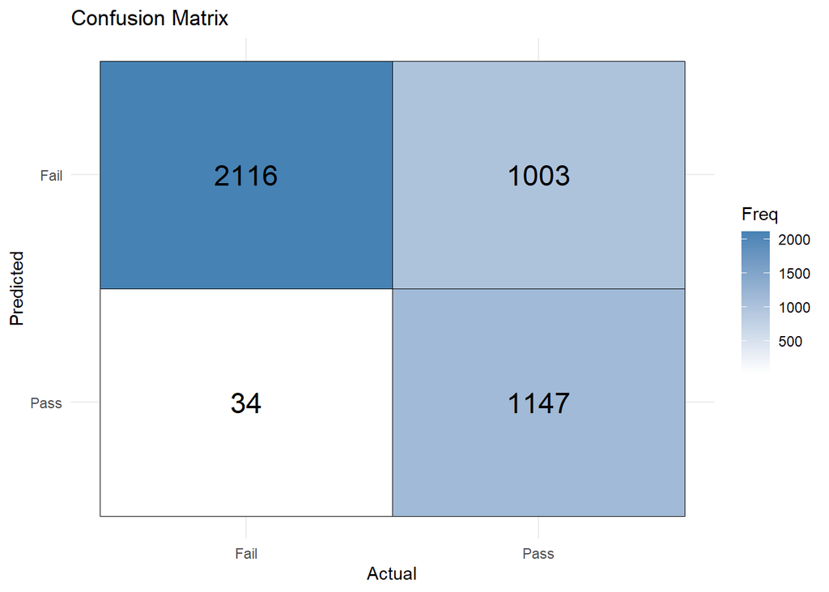

```r
tree_conf_mat <- confusionMatrix(rf_predictions, students$Pass_Fail, positive = 'Pass')
tree_conf_mat_df <- as.data.frame(tree_conf_mat$table)
ggplot(data = tree_conf_mat_df, aes(x = Reference, y = Prediction, fill = Freq)) +
  geom_tile(color = "black") +
  geom_text(aes(label = Freq), size = 6) +
  scale_fill_gradient(low = "white", high = "steelblue") +
  scale_y_discrete(limits = rev(levels(conf_mat_df$Prediction))) +
  theme_minimal() +
  labs(title = "Confusion Matrix", x = "Actual", y = "Predicted")
```

**RF Confusion Matrix**

On the x-axis, we have the actual outcomes — whether students passed or failed. On the y-axis, we have the model’s predictions. The model correctly predicted that 2,116 students would fail, and they did — these are the true negatives. It also correctly predicted that 1,147 students would pass — the true positives. However, the model incorrectly predicted that 1,003 students would fail when they actually passed — these are false negatives. Only 34 students were wrongly predicted to pass when they actually failed — these are the false positives.

The model is very cautious and tends to predict failure more often than success. This results in many false negatives, where students who would actually pass are incorrectly predicted to fail. Essentially, the model is good at identifying students who are likely to fail, but it struggles more when it comes to predicting students who will pass. This aligns with what we saw earlier, where the RF model shows high specificity (correctly identifying failures) but only moderate sensitivity (missing some students who will pass).

```r
rf_probs <- predict(rf_model, students, type = "prob")[,2]

rf_roc <- roc(students$Pass_Fail, rf_probs)
```

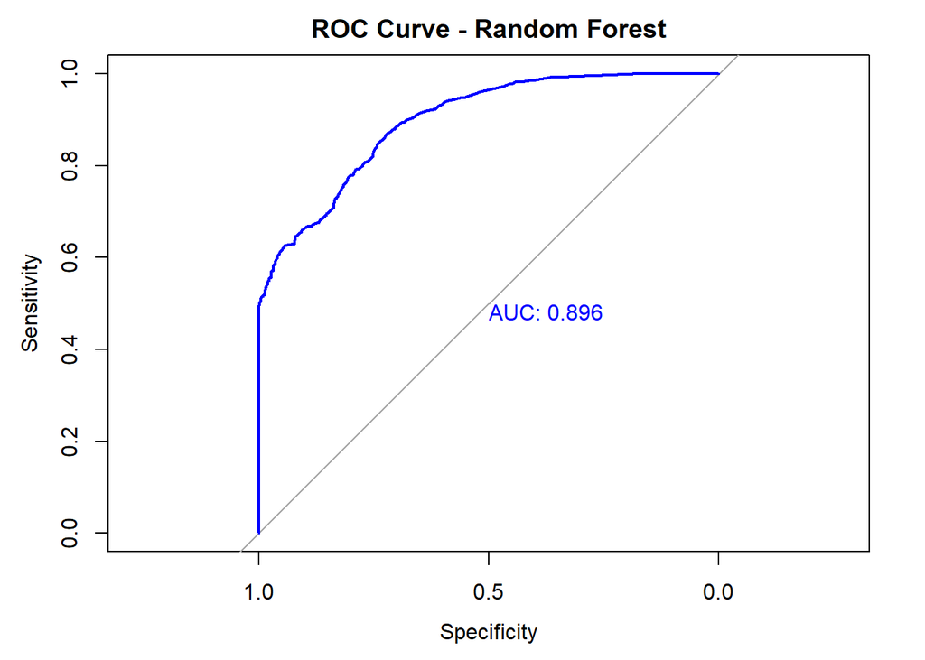

```r
plot(rf_roc,
     main="ROC Curve - Random Forest",
     print.auc = TRUE,
     col = "blue",
     lwd = 2)
```

**RF ROC Curve**

The ROC curve helps us visualize the trade-off between sensitivity and specificity at various threshold levels.As a rule of thumb, an AUC — or Area Under the Curve — greater than 0.8 is considered good, and anything above 0.85 is excellent.

In our case, the AUC is 0.896, which is excellent! This tells us that the model is highly capable of distinguishing between students who will pass and those who will fail — even when we vary the decision threshold. So, overall, this ROC analysis reinforces that our model performs very well.

```r
importance(rf_model)
```

```
##                                 Fail       Pass MeanDecreaseAccuracy
## Attendance                 111.26896 108.946641            114.87554
## Family_Income_Level         33.07132  -1.171033             26.11730
## Extracurricular_Activities  24.78908  -5.658143             17.20357
## Internet_Access_at_Home     26.04556  -5.975607             18.14491
##                            MeanDecreaseGini
## Attendance                       855.826578
## Family_Income_Level               15.897871
## Extracurricular_Activities         8.459240
## Internet_Access_at_Home            7.054061
```

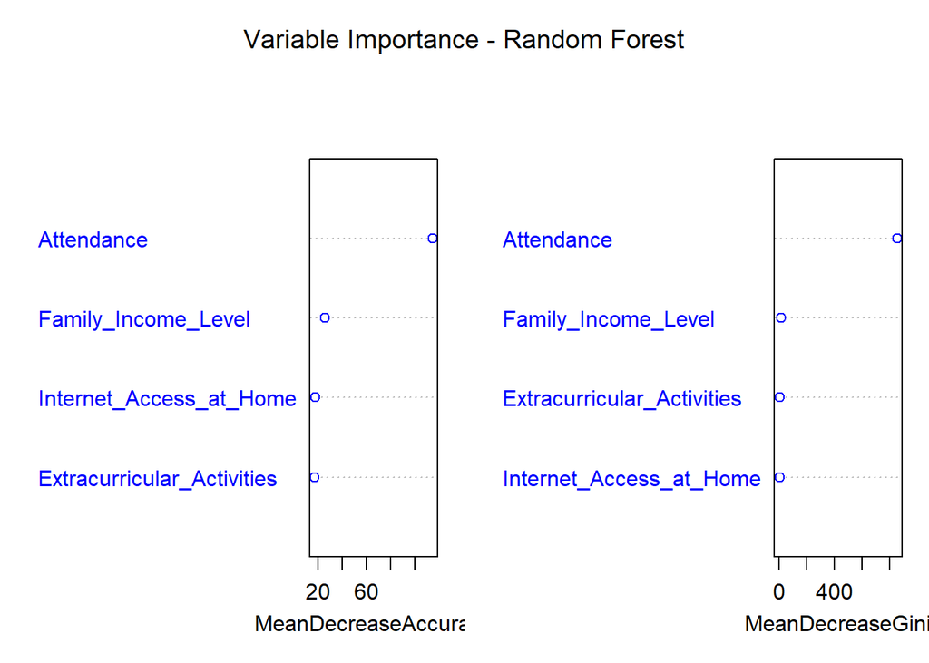

```r
varImpPlot(rf_model,
           main = "Variable Importance - Random Forest",
           col = "blue",
           lwd = 2)
```

**Variable Importance**

This helps us to confirm that attendance is the most important variable in predicting pass/fail, supporting our initial assumption from the results of the logistic regression model. This plot visualizes how much each variable contributes to the predictive accuracy of the Random Forest model. The higher the mean decrease in accuracy, the more important the variable. In this case, the large contribution of attendance indicates that it plays a central role in student performance.

Sensitivity : 0.6935

Specificity : 0.7144

# Comparing Logistic Regression to Random Forest:

**Logistic Regression**

- True pass rate of 69.35%
- True fail rate of 71.44%
- AUC(ROC): 0.804

**Random Forest**

- True pass rate of 53.35%
- True fail rate of 98.42%
- AUC(ROC): 0.896

**Comparing the performance of Logistic Regression and Random Forest** based on three key metrics: Pass Recall, Fail Recall, and AUC.

Pass Recall is higher for Logistic Regression — about 69.35%, compared to 53.35% for Random Forest. This means Logistic Regression is better at identifying students who will pass. However, Fail Recall tells a different story — Random Forest outperforms Logistic Regression significantly, correctly identifying 98.42% of students who will fail, compared to only 71.44% by Logistic Regression. Looking at the AUC, Random Forest scores 0.896, which is excellent, while Logistic Regression scores 0.804, which is still acceptable but not as strong.

Therefore, which model to use is dependent on the professors use case. If the professor wants a balanced model, which predicts passing and failing at a fairly even rate, it is recommended to use logistic regression. However, if the professor wants to identify students who are likely to fail, the random forest model is the better choice. In most use cases, we would expect the professor to use the random forest model, as it is more important for students to know what is likely to lead them to failing.

Ultimately, the choice of model depends on the specific goals of the professor or the intervention strategy being used.

# Conclusion

Attendance is the strongest predictor of student success. As students attend more classes, their chances of passing increase. Professors should make it clear to students that attending class is very important. Furthermore, although family income did not show a strong effect based on p-value, other methods suggested it may still have some impact on a students likelihood to pass the course. This could point to hidden issues or unfair disadvantages and would require further analysis. Overall, both models used—Random Forest and Logistic Regression—worked well but serve different goals. Random Forest is better for spotting students who might fail, while Logistic Regression is moderate st both, making for a balanced model. Ultimately, both models strongly indicate that attendance really matters.